# Effect of autocorrelation in x on cross-correlation between x and y

Oliver Cutbill

2023-01-29

## Problem

Let $X_t$, $Y_t$ with $t = 1, \dots, n$ be two continuous time-series. A typical piece of information of interest is the cross-correlation of the two series. That is, we are interested in:

$$\operatorname{Cov}\left(X_t, Y_{t+h}\right) = f(h), \thinspace h \in
\mathbb{Z}$$
However, suppose that the autocorrelation in one of the variables (WLOG $X_t$), $\operatorname{Cov(X_t, X_{t+h})}$ is high. This note gives a brief explanation of the consequences of high autocorrelation in one variable for the bivariate cross-correlation function $f$. In particular, I conclude that cross-correlation is *not* useful when autocorrelation in one variable is high.

## Simulated results

In this section, I simulate two variables from a bivariate normal distribution with a mild positive correlation of 0.6.

```r
library(faux)
set.seed(2023)

data <- faux::rnorm_multi(n = 10^3,
                    mu = 0,
                    sd = 1,
                    r = 0.6,
                    vars = 2,
                    varnames = c("X", "Y"),
                    empirical = TRUE)
```

The autocorrelation in each variables is low:

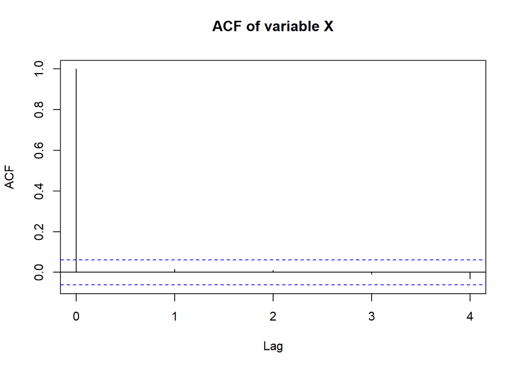

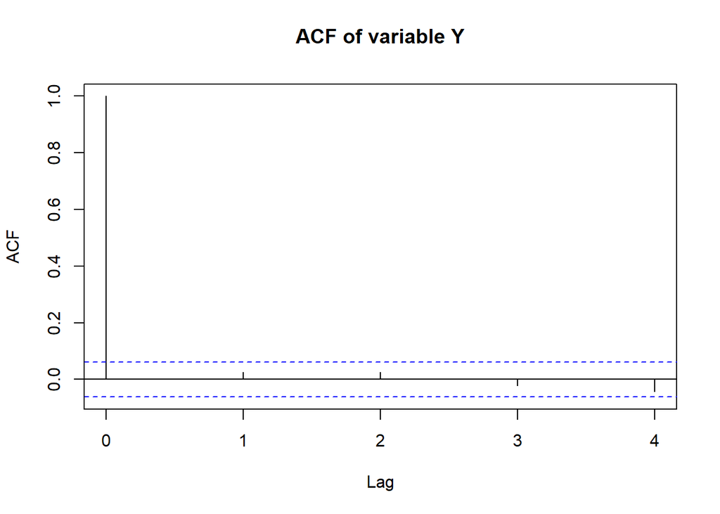

```r
imap(data, ~ acf(x = .x, lag.max = 4, plot = TRUE, main = paste("ACF of variable", .y)))
```

The cross-correlation function (the object of interest) shows little lag/lead structure between the variables:

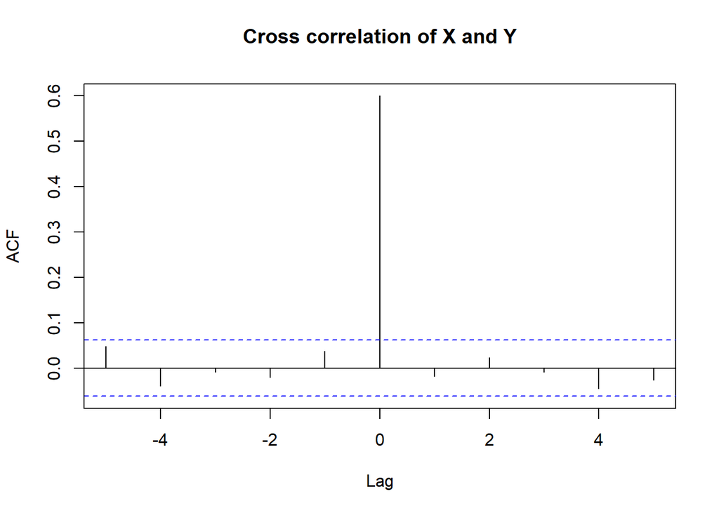

Now I adjust $X$ to have serial correlation:

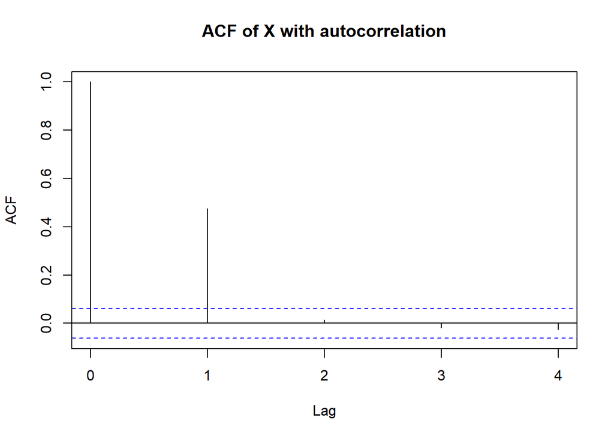

```r
data$X_adjusted <- stats::filter(data$X, filter = 2:3, circular = TRUE)
acf(data$X_adjusted, lag.max = 4, main = "ACF of X with autocorrelation")
```

Note that the new variable $X_{\text{adjusted}}$ still has a similar correlation with $Y$ as $X$:

```
## [1] "The correlation of X and Y is 0.6 and the correlation of X (with autocorrelation) and Y is 0.49"
```

Let’s now compare the cross-correlation functions. The way to read the charts below is tick along the x-axis is the parameter $h$, and the y-axis is $\operatorname{Cov}(X_t, Y_{t+h})$.

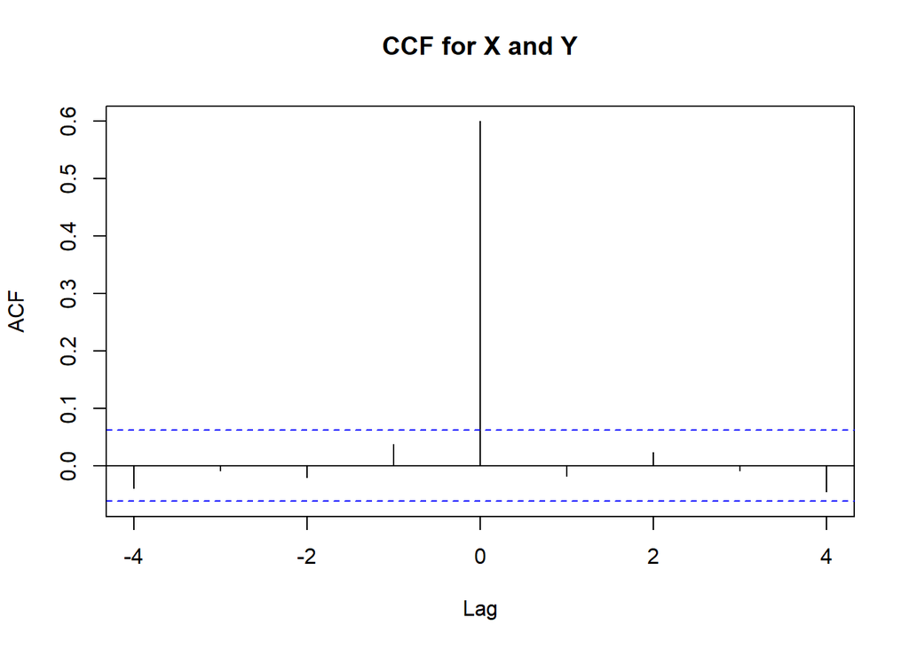

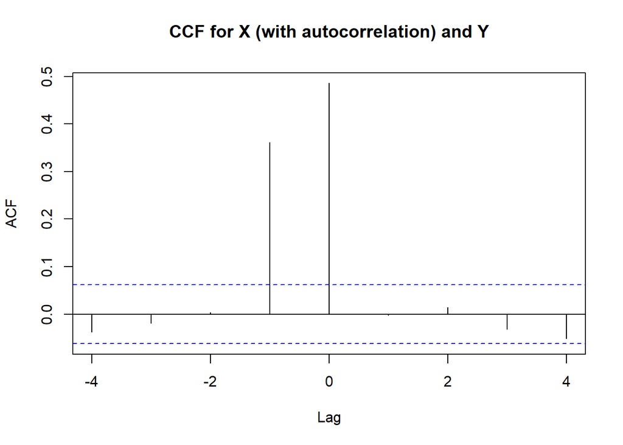

```r
ccf(x = data$X, y = data$Y, lag.max = 4, main = "CCF for X and Y"); ccf(x = data$X_adjusted, y = data$Y, lag.max = 4, main = "CCF for X (with autocorrelation) and Y")
```

Note that the right ccf now ‘finds’ a lag structure between the two variables!